# Лабораторная работа №2

Презентация

Андрюшин Н. С.

Российский университет дружбы народов, Москва, Россия

25 февраля 2024

# Информация

## Докладчик

- Андрюшин Никита Сергеевич
- Студент
- Российский университет дружбы народов
- 1132231848@pfur.ru

## Цель

Изучить идеологию и применение средств контроля версий. Освоить умения по работе с git

## Задачи

Создать базовую конфигурацию для работы с git. Создать ключ SSH. Создать ключ PGP. Настроить подписи git. Зарегистрироваться на Github. Создать локальный каталог для выполнения заданий по предмету.

## Установка git

Для начала установим git. В моём случае он уже установлен

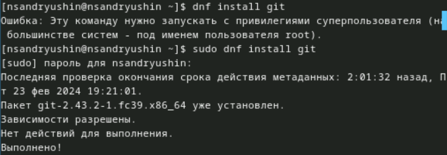

Установка git

## Установка gh

Теперь установим gh

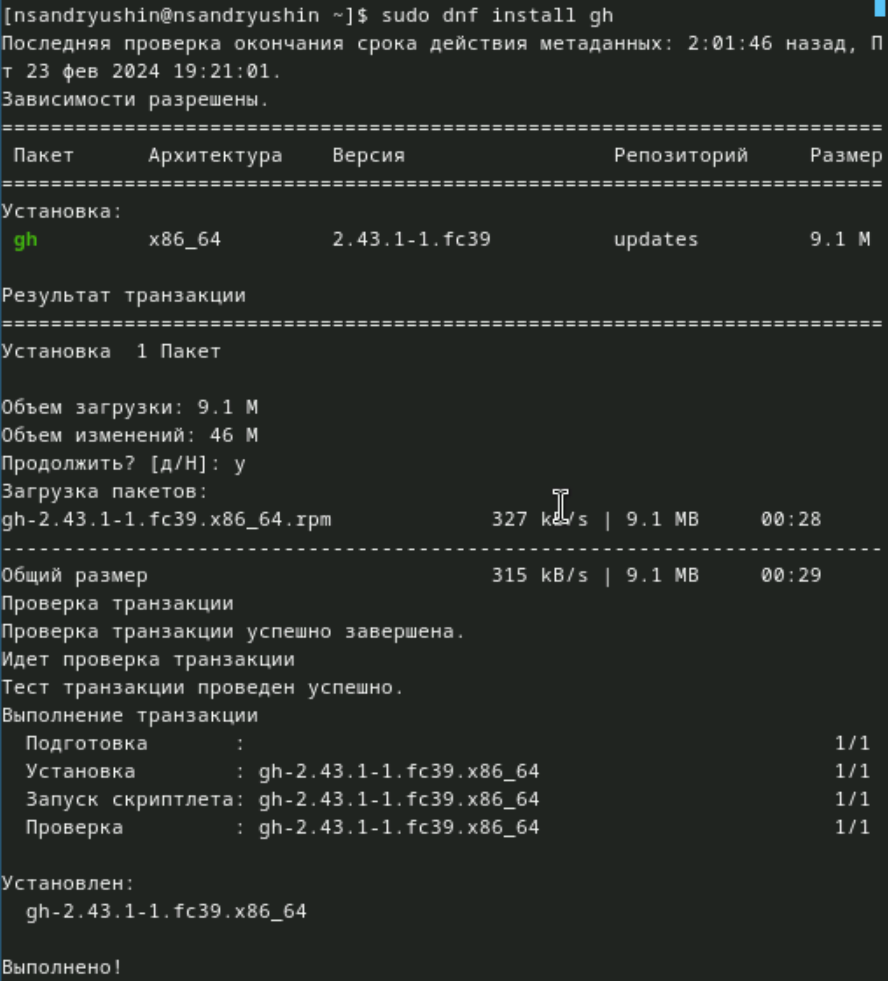

Установка gh

## Базовая настройка git

Далее, зададим имя для владельца репозитория. В данном случае это моё имя

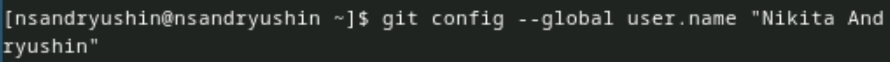

Указание имени

## Базовая настройка git

Теперь зададим почту. Я задал почту, на которую у меня зарегистрирован аккаунт на github

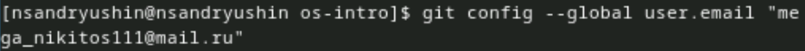

Указание почты

## Базовая настройка git

Настроим кодировку utf8 в выводе сообщений git

## Базовая настройка git

Зададим имя начальной ветки, настроим параметры autocrlf и safecrlf

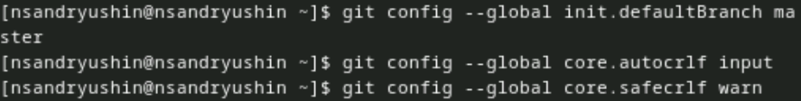

Настройка git

## Создание ключа ssh

Создадим ключ RSA размером 4096 бит

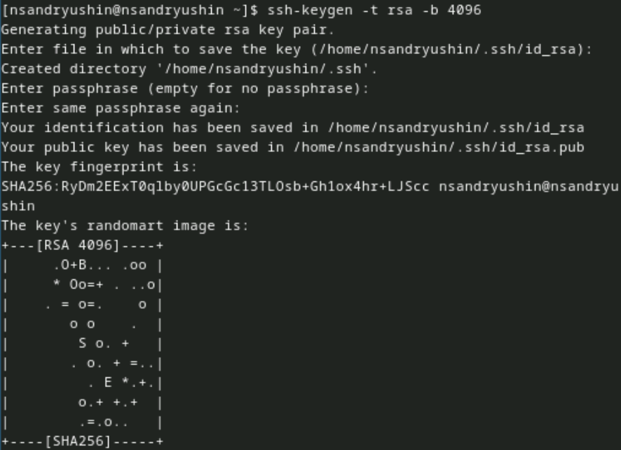

Создание ключа RSA

## Создание ключа ssh

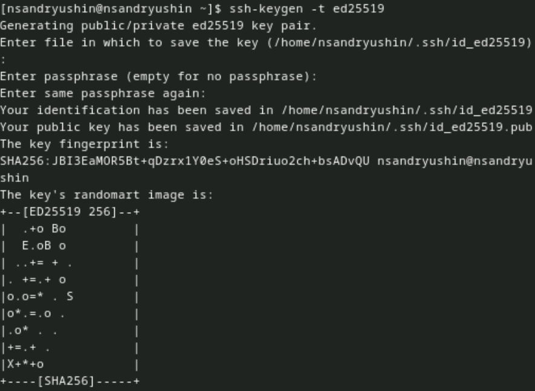

## Создание ключа pgp

Теперь создадим ключ gpg. Выбираем из предложенных вариантов первый тип (RSA and RSA), размер ключа задаём 4096 бит и делаем срок действия ключа неограниченным

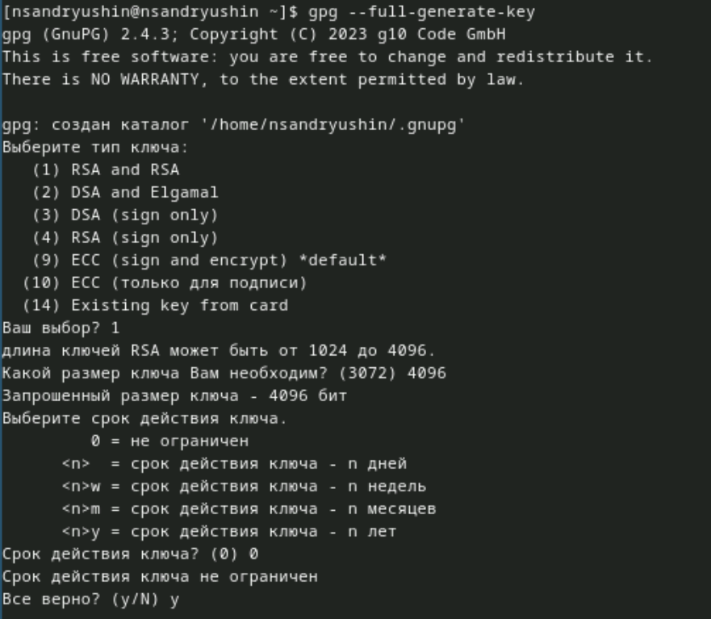

оздание ключа pgp (1)

## Создание ключа pgp

После нас попросят ввести свои данные. Мы вводим имя и адрес электронной почты. После этого соглашаемся с генерацией ключа

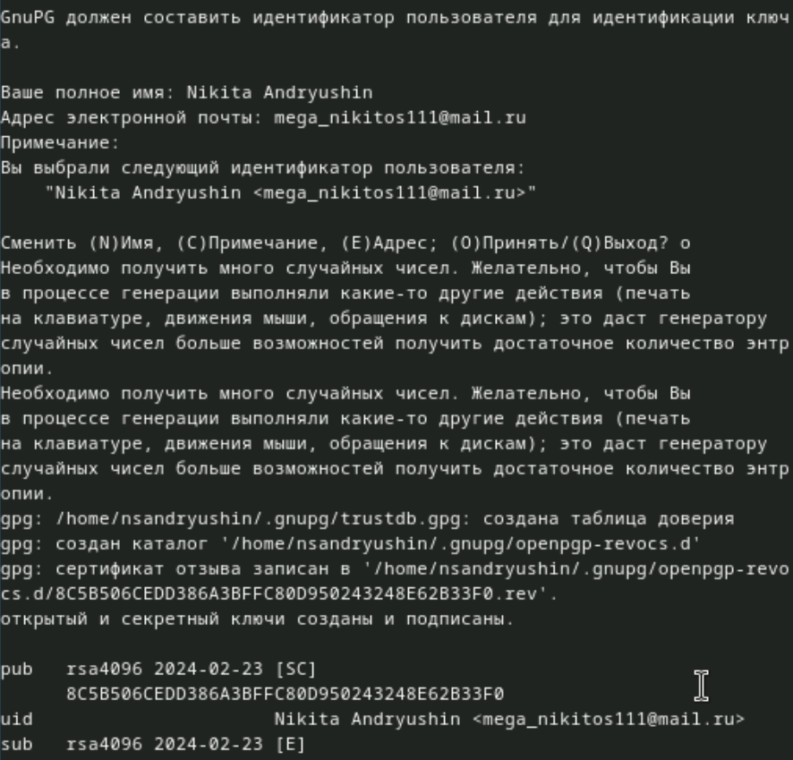

оздание ключа pgp (2)

## Добавление PGP ключа в GitHub

Далее, выводим список pgp ключей

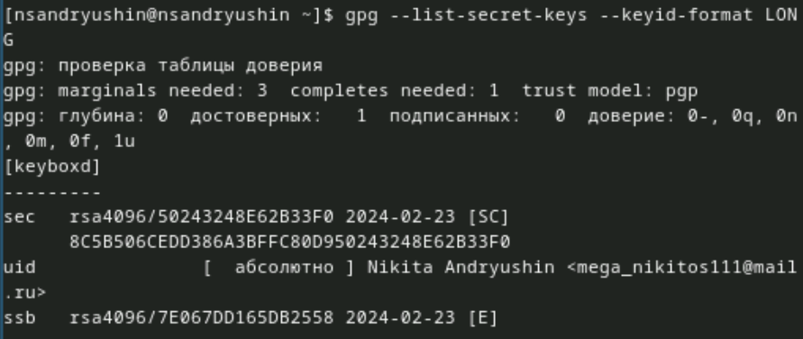

Список pgp ключей

## Добавление PGP ключа в GitHub

Копируем наш ключ в буфер обмена

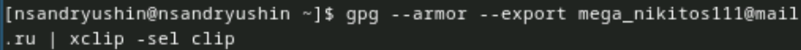

Копирование ключа

## Добавление PGP ключа в GitHub

Вставляем этот ключ на гитхаб, и задаём ему имя. Я выбрал имя Sway

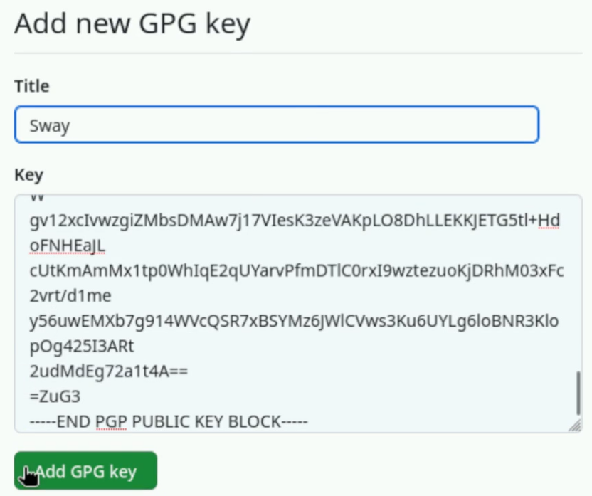

Вставка ключа в GitHub

## Настройка автоматических подписей коммитов git

Теперь производим настройку автоматических подписей

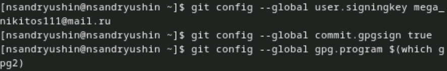

Настройка автоматических подписей коммитов git

## Настройка gh

После, нам нужно авторизоваться в github с помощью gh. Мы выбираем сайт для авторизации (GitHub.com), после выбираем предпочитаемый протокол (SSH), публичный SSH ключ (id_rsa.pub), и имя для ключа (Sway). В качестве способа авторизации выбираем авторизацию через браузер

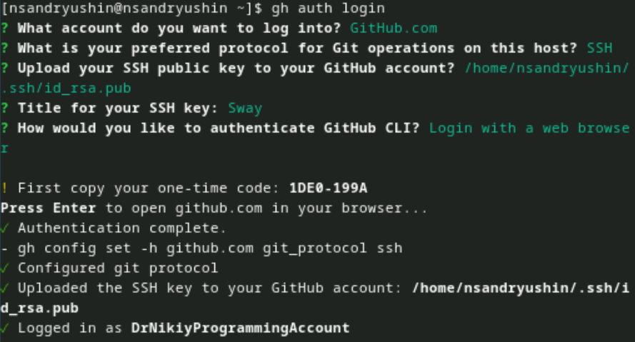

Авторизация в gh

## Сознание репозитория курса на основе шаблона

Теперь создаём рабочую директорию курса и переходим в неё

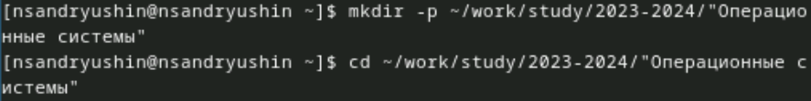

Создание рабочей директории и переход в неё

## Сознание репозитория курса на основе шаблона

Далее, создаём репозиторий для лабораторных работ из шаблона

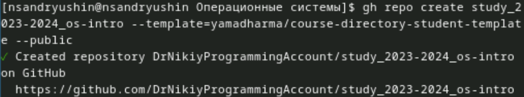

Сознание репозитория курса

## Сознание репозитория курса на основе шаблона

И клонируем его к себе на компьютер

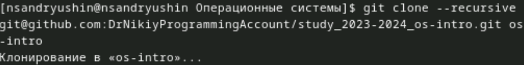

Клонирование репозитория

## Настройка каталога курса

Переходим в него с помощью cd и удаляем ненужные файлы (package.json) и создаём необходимые каталоги, записав в файл COURSE строку os-intro (это наш текущий курс) и прописываем make prepare для того, чтобы нужные нам каталоги создались

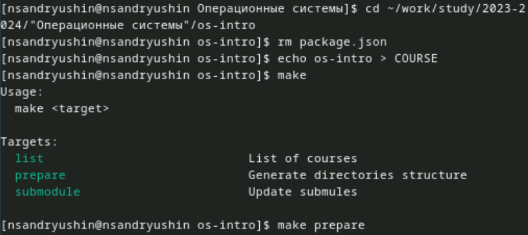

Удаление ненужных файлов и использование make

## Настройка каталога курса

Теперь добавляем нашу папку для отправки

## Настройка каталога курса

Делаем коммит, в котором указываем, что мы сделали структуру курса

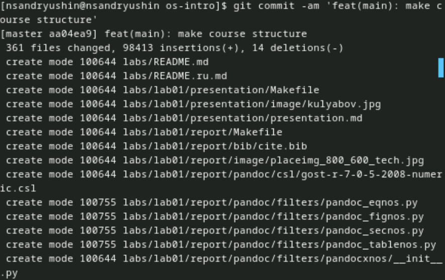

Использование git commit

## Настройка каталога курса

И отправляем файлы на сервер GitHub с помощью команды push

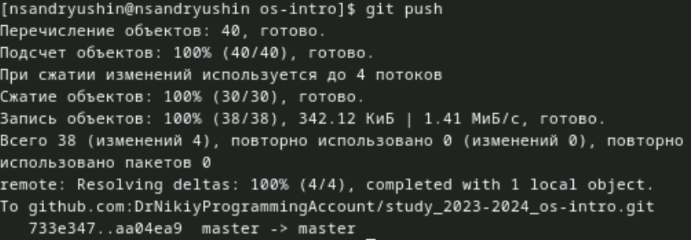

Использование git push

## Выводы

Была произведена установка git, проведена его первоначальная настройка, были созданы ключи для авторизации и подписи, а также создан репозиторий курса из предложенного шаблона